# LogisticSimPublic.R

VNOB-0735

2023-01-17

# Think before you shrink

Script: Mark van de Wiel, mark.vdwiel@amsterdamumc.nl

Script allows for repeating calculations as performed in the Manuscript: “Think before you shrink: Alternatives to default shrinkage methods can improve prediction accuracy, calibration and coverage”.This script presents results for logistic regression on simulated data. Results for linear regression are presented in the HeliusSubsetsPublic.R script. Note: results may deviate slightly from those in the manuscript, due to use of different simulated sets.

Script evaluates predictive performance in terms of accuracy and calibration for several shrinkage methods, including some Bayesian ones. Focus lies on variations of ridge-type shrinkage.

## Preliminaries

Load libraries; Using suppressWarnings() to avoid clutter

```r
suppressWarnings(library(logistf)) #for Firth
library(glmnet) #for logistic ridge
library(MASS) #for sampling covariates from mvt normal
library(rstan) #for Bayesian ridge variations
```

Source code that includes the fitting functions.

```r
#setwd() #to change working directory
source('LogisticSimPublic_functions.R')
```

Compiles stan code for Bayesian fits; takes some time

```r
pmt <- proc.time()
stan_bin_brl_HalfCauchy <- stan_model(model_name = "stan_bin_brl_HalfCauchy", model_code = code_bin_brl_HalfCauchy)
stan_bin_brg_HalfCauchy <- stan_model(model_name = "stan_bin_brg_HalfCauchy", model_code = code_bin_brg_HalfCauchy)
proc.time()-pmt
```

```
##    user  system elapsed
##    1.03    0.24   63.58
```

## Simulation

Simulation set-up. Manuscript presents three (x3) scenarios. All can be reproduced here. 1. Sample n=50, beta1 = c(0.2,0.2,0.2,0.5,0.8) [Main document] 2. As 1, but with n=100 [Supp Mat] 3. As 1. but with 5 zero’s added to the beta vector. [Supp Mat] For all these scenarios, three settings of beta are considered: weak: beta = beta1/3, normal: beta=beta1, strong: beta = 3*beta1.`

Sample size

```r
n = 50
#n =100
```

Add 5 zeros to beta vector?

```r
addzeros <- FALSE
#addzeros <- TRUE
```

weak, normal or strong betas?; Correspond to left, middle and right panels in manuscript

```r
setting <- "normal"
#setting < - "weak"
#setting <- "strong"
```

Event probability

```r
PE = 0.5
```

Nr of simulations. Equals 50 for manuscript, but you may want to set it to a lower number to try the fitting first

```r
iter = 50
```

Correlation in X

```r
rho = 0.5
```

Regression coefficients

```r
beta1 = c(0.2,0.2,0.2,0.5,0.8)
if(setting == "weak") beta1 = beta1/3
if(setting == "strong") beta1 = beta1*3
if(addzeros) beta1=c(rep(0,5),beta1)           # add 5 "noise" predictors
k = length(beta1)
```

File for storing results; state working directory for storing results

```r
wd <- "C:\\ExternData\\Helius\\"
fileout <- paste(wd,"logisticsim","_n",n,"_rho",rho,"_PE",PE,"_addzeros",addzeros,"_betas",setting,".Rdata",sep="")
fileout
```

```
## [1] "C:\\ExternData\\Helius\\logisticsim_n50_rho0.5_PE0.5_addzerosFALSE_betasnormal.Rdata"
```

Simulate test covariates

```r
set.seed(123)
S = matrix(rho,k,k)
diag(S) = 1
x.test = mvrnorm(10^5,mu=rep(0,k),Sigma=S)
```

Compute beta0 to meet desired PE

```r
tmp = function(beta0){
  lp = beta0 + x.test %*% beta1
  mean(1/(1+exp(-lp))) - PE
}
beta0 = uniroot(tmp,interval=c(-10,10))$"root"
beta = c(beta0,beta1)
beta
```

```
## [1] -1.887002e-06  2.000000e-01  2.000000e-01  2.000000e-01  5.000000e-01
## [6]  8.000000e-01
```

Results test set using true coefficients

```r
Xtest = cbind(1, x.test)
lp.test <- Xtest %*% beta
prob.test = 1/(1+exp(-lp.test))
ntest <- length(lp.test)
ytest <- rbinom(ntest,1,prob.test)
```

Simulate training data, perform fits, and compute MSEs. Takes considerable time; consider running with a low value of iter first. Note: you may ignore any error message of the type: ‘possible Error in x$.self$finalize() : attempt to apply non-function’. This is harmless. suppressWarnings() is used to avoid clutter.

```r
pt0 <- proc.time()
simres <- suppressWarnings(simandfit(iter,n,k,S,beta0,beta1,Xtest,prob.test))
```

```
## [1] 5
## [1] 10
## [1] 15
## [1] 20
## [1] 25
## [1] 30
## [1] 35
## [1] 40
## [1] 45
## [1] 50
```

```r
totaltime <- proc.time()-pt0
totaltime
```

```
##    user  system elapsed
##  576.88    0.53  580.43
```

```r
allbs <- simres$allbs;mse <- simres$mse; time <- simres$time
save(setting, addzeros, totaltime, allbs, mse, time, beta1, Xtest, lp.test, file = fileout)
```

## Analysis and plot simulation results

Load simulation results if stored in a file

```r
#load("logisticsim_n50_rho0.5_PE0.5_addzerosFALSE_betasnormal.Rdata")
```

Computes cslope

```r
pmt <- proc.time()
slope = matrix(0,length(allbs),6)
for(i in 1:length(allbs)){
bs <- allbs[[i]]
lps <- Xtest %*% bs
  for(k in 1:6){
  slope[i,k] = coef(lm(lps[,k] ~ lp.test))[2]
  }
}
proc.time()-pmt
```

```
##    user  system elapsed
##    9.43    1.11   10.54
```

Computes classical calibration slopes; takes some time

```r
pmt <- proc.time()
calslope = matrix(0,length(allbs),6)
for(i in 1:length(allbs)){
  bs <- allbs[[i]]
  lps <- Xtest %*% bs
  for(k in 1:6){
    calslope[i,k] = coef(glm(ytest ~ lps[,k],family="binomial"))[2]
  }
}
proc.time()-pmt
```

```
##    user  system elapsed
##   99.67    9.26  109.12
```

Plots cslope and MSE

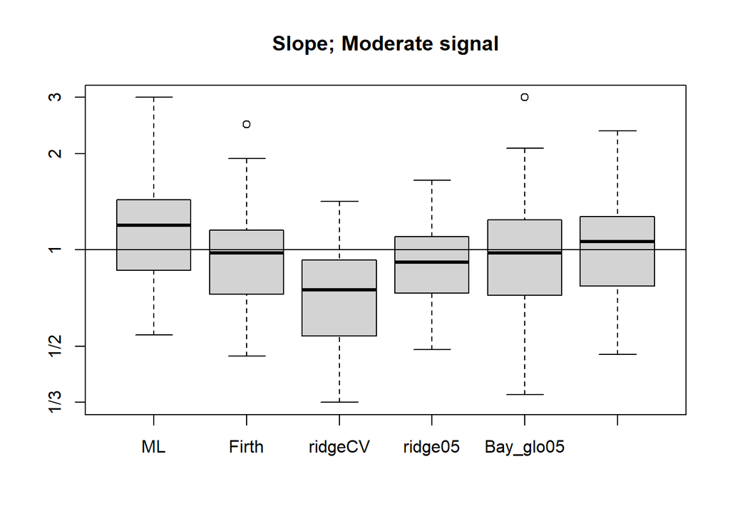

```r
  dfslopemat0 <- apply(apply(slope,c(1,2),min, y=3), c(1,2),max, y=1/3)
  cols <- c(1,6,3,2,5,4)
  dfslopemat <- dfslopemat0[,cols]
  colnames(dfslopemat) <- c("ML","Firth","ridgeCV","ridge05","Bay_glo05","Bay_loc05")
  if(setting == "weak") la <- "Slope; Weak signal"
  if(setting == "normal") la <- "Slope; Moderate signal"
  if(setting == "strong") la <- "Slope; Strong signal"
  par(yaxt="n")
  boxplot(log(dfslopemat,3),xlab="",main=la, ylim=c(-1,1))
  abline(h=0)
  par(yaxt="s")
  axis(2,at=c(-1,log(1/2,3),0,log(2,3),1),labels=c("1/3","1/2","1","2","3"))
```

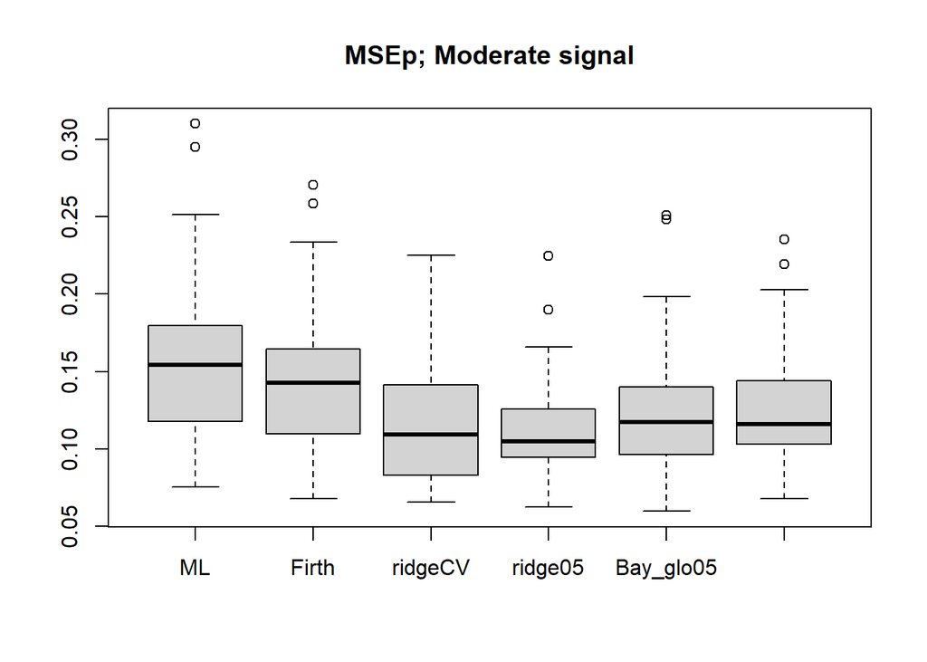

```r
  dfMSEmat0 <- mse
  dfMSEmat <- dfMSEmat0[,cols]
  colnames(dfMSEmat) <- c("ML","Firth","ridgeCV","ridge05","Bay_glo05","Bay_loc05")
  if(setting == "weak") la <- "MSEp; Weak signal"
  if(setting == "normal") la <- "MSEp; Moderate signal"
  if(setting == "strong") la <- "MSEp; Strong signal"
  boxplot(dfMSEmat,xlab="", main=la)
```

Plots inverted cslope and classical calibration slope

```r
  dfslopemat0 <- apply(apply(1/slope,c(1,2),min, y=10), c(1,2),max, y=1/10)
  c("ML", "glmnet05","glmnet_cv","bayes_loc05", "bayes_glo05", "firth")
```

```
## [1] "ML"          "glmnet05"    "glmnet_cv"   "bayes_loc05" "bayes_glo05"
## [6] "firth"
```

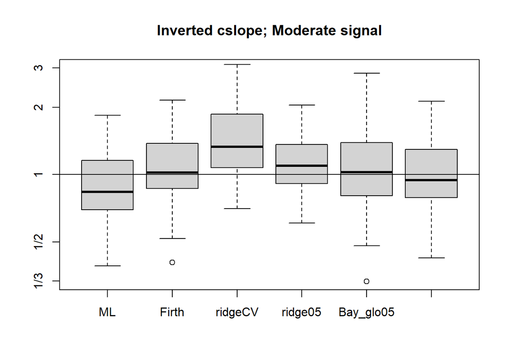

```r
  cols <- c(1,6,3,2,5,4)
  dfslopemat <- dfslopemat0[,cols]
  colnames(dfslopemat) <- c("ML","Firth","ridgeCV","ridge05","Bay_glo05","Bay_loc05")
  if(setting == "weak") la <- "Inverted cslope; Weak signal"
  if(setting == "normal") la <- "Inverted cslope; Moderate signal"
  if(setting == "strong") la <- "Inverted cslope; Strong signal"
  par(yaxt="n")
  boxplot(log(dfslopemat,3),xlab="",main=la, ylim=c(-1,1))
  abline(h=0)
  par(yaxt="s")
  axis(2,at=c(log(1/10,3),-1,log(1/2,3),0,log(2,3),1,log(10,3)),labels=c("1/10", "1/3","1/2","1","2","3","10"))
```

```r
  dfslopemat0 <- apply(apply(calslope,c(1,2),min, y=10), c(1,2),max, y=1/10)
  c("ML", "glmnet05","glmnet_cv","bayes_loc05", "bayes_glo05", "firth")
```

```
## [1] "ML"          "glmnet05"    "glmnet_cv"   "bayes_loc05" "bayes_glo05"
## [6] "firth"
```

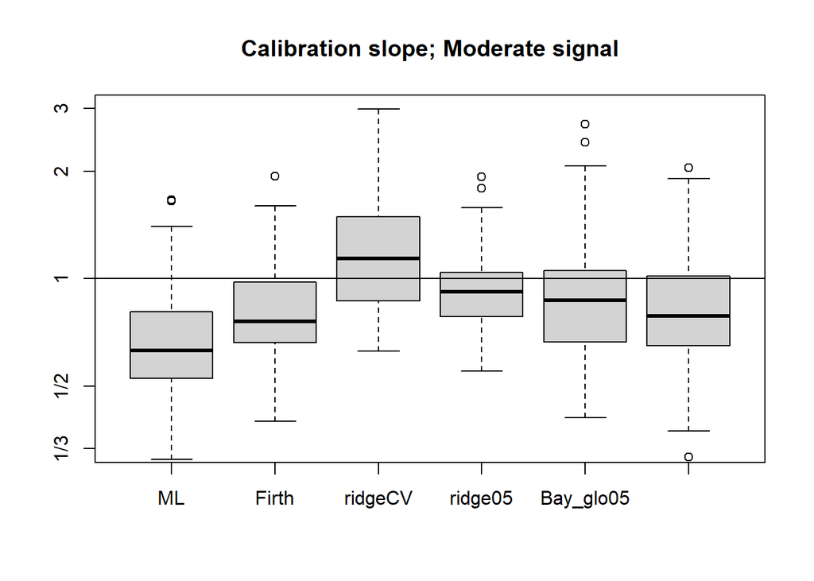

```r
  cols <- c(1,6,3,2,5,4)
  dfslopemat <- dfslopemat0[,cols]
  colnames(dfslopemat) <- c("ML","Firth","ridgeCV","ridge05","Bay_glo05","Bay_loc05")
  if(setting == "weak") la <- "Calibration slope; Weak signal"
  if(setting == "normal") la <- "Calibration slope; Moderate signal"
  if(setting == "strong") la <- "Calibration slope; Strong signal"
  par(yaxt="n")
  boxplot(log(dfslopemat,3),xlab="",main=la, ylim=c(-1,1))
  abline(h=0)
  par(yaxt="s")
  axis(2,at=c(log(1/10,3),-1,log(1/2,3),0,log(2,3),1,log(10,3)),labels=c("1/10", "1/3","1/2","1","2","3","10"))
```